```r
library(tidyverse)
library(forecast)
```

# Importations des données

Tout d’abord, on importe les données et on sélectionne les données concernant la France.

```r
donnees_fr <- read.csv("covid_france.csv",sep=",")
summary(donnees_fr)
```

```
##      date             new_cases
##  Length:1203        Min.   :     0
##  Class :character   1st Qu.:  2968
##  Mode  :character   Median : 12174
##                     Mean   : 32315
##                     3rd Qu.: 32913
##                     Max.   :500563
##                     NA's   :1
```

Les données ci-dessus comprennent une variable temporelle et une variable caractérisée par un enregistrement journalier des nouveaux cas de Covid-19 en France.

```r
min(donnees_fr$date)
```

```
## [1] "2020-01-03"
```

```r
max(donnees_fr$date)
```

```
## [1] "2023-04-19"
```

## Transformation des données en série temporelle

Premièrement, nous allons transformer nos données en séries temporelles pour pouvoir réaliser notre analyse.

```r
ts_donnees_fr <- ts(donnees_fr$new_cases,start = c(2020,1,3), frequency = 365)
# class(ts_donnees_fr)
```

# Première partie

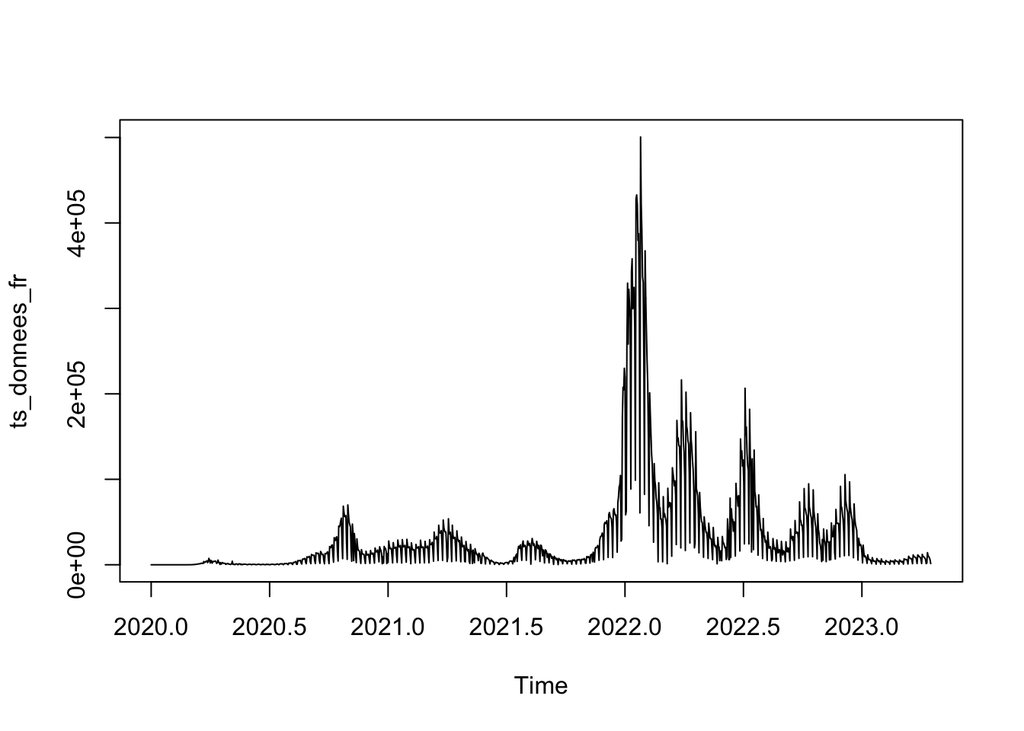

```r
plot(ts_donnees_fr)
```

Ce premier graphique nous montre une hausse brutale des nouveaux cas de covids en 2022. Afin de pouvoir continuer notre analyse de façon cohérente, nous allons diviser notre série en 3 parties : avant, pendant et après ce choc en 2022.

## Division de notre série

Nous décidons de créer trois sous-séries de notre série initiale afin de pouvoir réaliser le traitement des données. Notre objectif est d’isoler le cas particulier de l’année 2022 pour avoir une étude correcte.

```r
serie1 <- donnees_fr |>
  filter(date<="2021-12-22")
# serie1
ts_serie1 <- ts(serie1$new_cases,start = c(2020,1,3), frequency = 365)



serie2 <- donnees_fr |>
  filter(date>"2021-12-22", date<="2023-01-05")
# serie2

ts_serie2 <- ts(serie2$new_cases,start = c(2021,31,12), frequency = 365)



serie3 <- donnees_fr |>
  filter(date>"2023-01-05")

ts_serie3 <- ts(serie3$new_cases,start = c(2023,2,5), frequency = 365)
```

Nous avons choisi de scinder notre série en trois périodes : - avant le 22 Décembre 2021 - entre le 23 Décembre 2021 et le 5 Janvier 2023 - après le 6 Janvier 2023

Nous pouvons maintenant les visualiser :

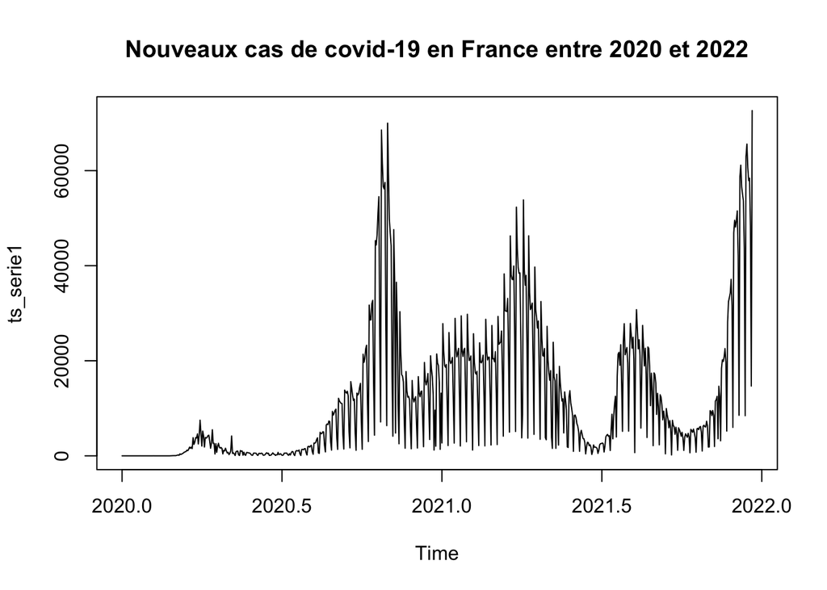

```r
plot(ts_serie1,main="Nouveaux cas de covid-19 en France entre 2020 et 2022")
```

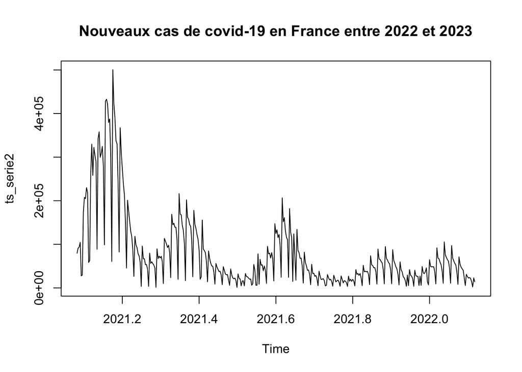

```r
plot(ts_serie2,main="Nouveaux cas de covid-19 en France entre 2022 et 2023")
```

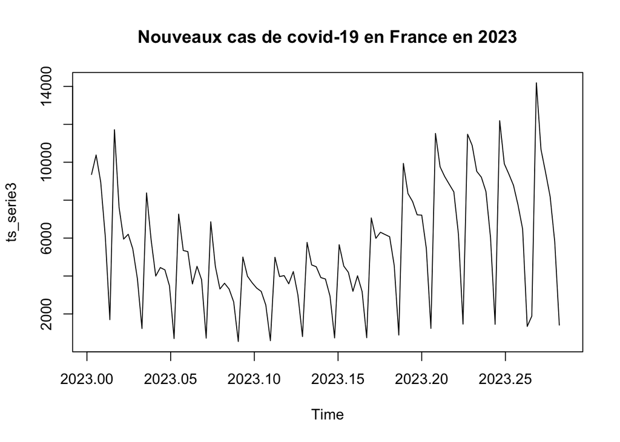

```r
plot(ts_serie3,main="Nouveaux cas de covid-19 en France en 2023")
```

Grâce à cette division, nous allons pouvoir étudier chaque sous-série pertinemment.

## Analyse de la première sous-série

Pour rappel, notre série présente une tendance à la hausse comme le montre le graphique ci-dessous. Elle présente aussi une saisonnalité, mais elle n’est pas régulière. En effet, les différentes hausses de nouveaux cas de covid dépendent des confinements et des mesures sanitaires mises en place.

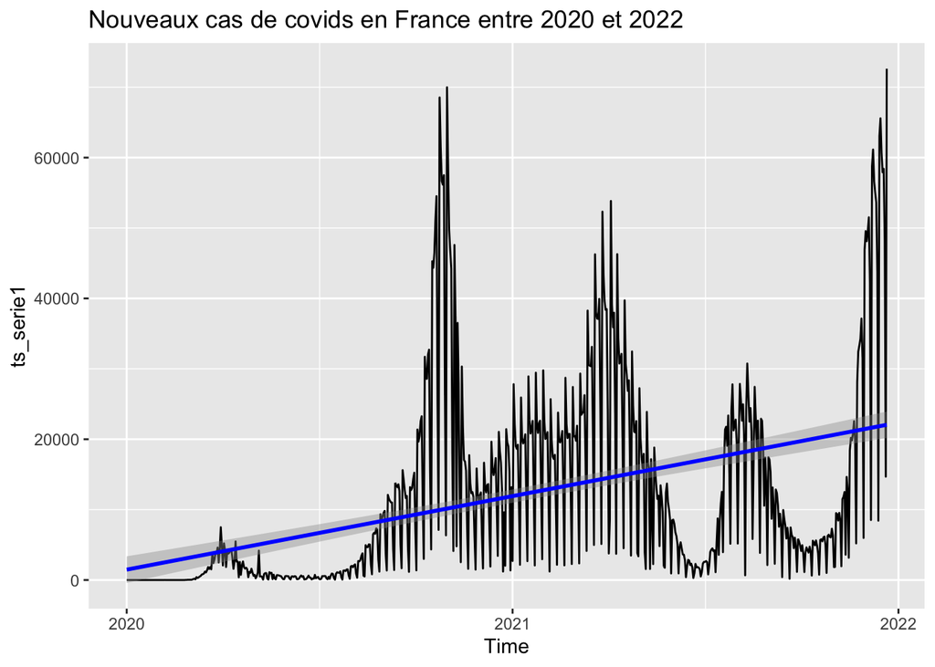

```r
autoplot(ts_serie1)+
  geom_smooth(method = lm,color="blue")+
  ggtitle("Nouveaux cas de covids en France entre 2020 et 2022")
```

On va d’abord chercher à décrire notre série grâce à des indicateurs descriptifs simples.

```r
mean(ts_serie1)
```

```
## [1] 11763.34
```

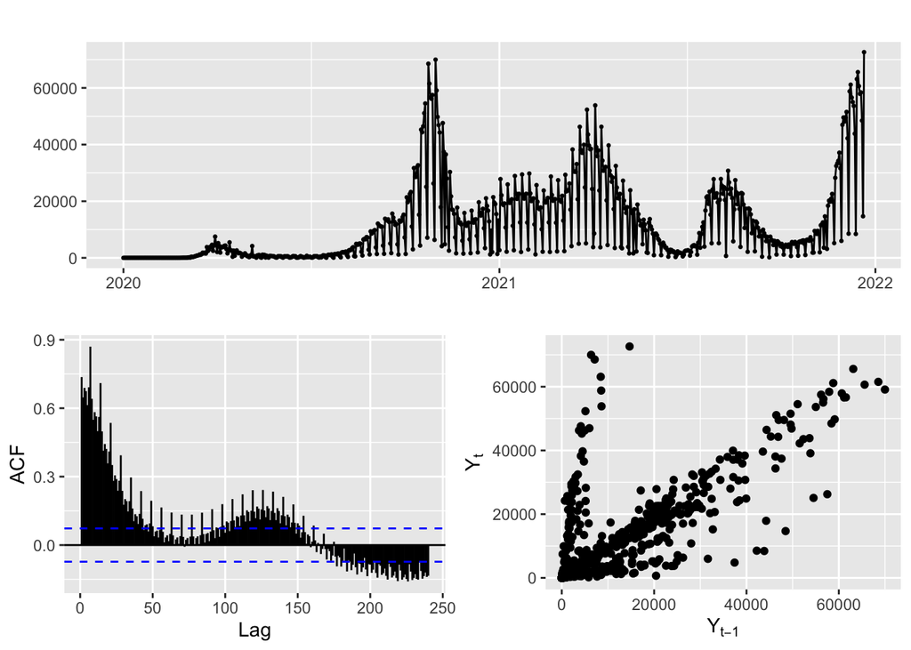

```r
ts_serie1 |>
  ggtsdisplay(plot.type = "scatter",smooth=FALSE)
```

Nous pouvons faire quelques observations sur le graphique de l’ACF. En effet, plusieurs autocorrélations présentent des valeurs significativement non nulles, ce qui signifie que la série chronologique n’est pas aléatoire.